# GEM500: Air Photos: Forest Disturbance

Jen Baron | University of British Columbia, Department of Forest and Conservation Sciences jenbaron@mail.ubc.ca

Sepetember 14, 2021

This lab is an adaptation in R of exercies 3.1 and 3.2 in Wallace, L. L & Gray, S. T. Feedbacks between organisms and ecosystem processes in Learning Landscape Ecology (1st Ed.) (2009).

# Materials

For this lab, you will need:

- A laptop with R & RStudio installed
- The Excel file (for data entry)
- A printed version of figure 17.1 (black & white)
- A ruler (in mm)
- Something to write with

# Introduction

Fall webworms (Hyphantria cunea), a generalist lepidopteran herbivore (member of the butterfly and moth group), provide an example of insects whose outbreaks interact with landscape structure. The larvae of the Hyphantria moth form silk tents over the foliage of deciduous trees, which they consume until reaching maturity. Work with similar lepidopteran herbivores has shown that many species choose locations in full sun over those in shaded environments (Louda and Rodman, 1996). Also, the severity of tent-forming caterpillar outbreaks is known to increase with forest fragmentation (Roland, 1993).

In the summer and fall of 1996, central Oklahoma experienced a severe outbreak of the fall webworm. During this time Wallace et al. performed a study to determine how forest structure influenced webworm distributions on the landscape shown in the aerial photograph in Figure 17.1. The locations of webworm-infested trees are identified with white circles. Edges of the forested areas and forested openings appear as lighter and gray while forested areas are darker gray and have a more “textured” appearance. You will conduct two different spatial analyses using the data collected in that study.

# Setup

## Set Working Directory

Your working directory is where R will look, by default, for files you ask it to load. It is also where, by default, any files you write to disk will go.

You can explicitly check your working directory with:

```r
getwd()
```

```
## [1] "C:/Users/jenbaron/Documents/UBC/Teaching/GEM500/2021/Labs/3_Air Photos II/Forest Disturbance/Master"
```

Although I don’t recommend it, you can set R’s working directory at the command line with `setwd("~/DirectoryName")` or going to Session -> Set Working Directory -> To Source File Location.

An excellent alternative is the `here` package enables easy file referencing by using the top-level directory of a file project to easily build file paths. This is in contrast to using setwd(), which is fragile and dependent on the way you order your files on your computer. This works, regardless of where the associated source file lives inside your project.

```r
library(here)
```

We are using a very simple file structure for this lab. However, in the future (e.g., for a research project) you may wish to set up more complex file directories (folders for data, figures, outputs, markdown) and may need to readily share your code with collaborators.

Read more about `here`:

- https://malco.io/2018/11/05/why-should-i-use-the-here-package-when-i-m-already-using-projects/
- http://jenrichmond.rbind.io/post/how-to-use-the-here-package/
- https://www.tidyverse.org/blog/2017/12/workflow-vs-script/

## Load Packages

R packages are collections of functions and data sets developed by the community. They increase the power of R by improving existing base R functionalities, or by adding new ones.

If you have never used these packages before, you will need to install them using `install.packages()`

```r
library(tidyr)
library(dplyr)
```

```r
library(ggplot2)
```

## 1. Demarcate Axes

First, use a ruler to demarcate axes for an x-y-coordinate system along the two edges of Figure 17.1.

## 2. Generate Coordinates

Use a random numbers generator to locate a random point in the photograph: generate a random number for the x-coordinate, and then another random number for the y-coordinate.

The range of numbers you select from will depend on how you draw your grid.

The `set.seed()` function sets the starting number used to generate a sequence of random numbers – it ensures that you get the same result if you start with that same seed each time you run the same process.

`sample` takes a sample of the specified size from the elements of x using either with or without replacement.

```r
set.seed(312) #the number you use here is arbitrary, as long as it's the same every time you run the code
#Change the seed, which will change the random numbers you generate

#Here I'm generating 15 x and y coordinates between the values of 0 and 20 (with replacement)
#Change the values (0:20) to reflect the grid you drew

x <- sample(0:20, 15, replace=TRUE)
y <- sample(0:20, 15, replace=TRUE)

as.data.frame(cbind(x,y))
```

```
##     x  y
## 1   9  7
## 2   9 10
## 3   7 15
## 4   3  4
## 5  12 20
## 6   3 19
## 7   2  5
## 8  14  2
## 9   2 11
## 10  4  1
## 11 13 15
## 12 12 18
## 13  6 11
## 14 16 13
## 15 13 12
```

## 3. Measure Distance

**Note: Enter your data into the “webworms” Excel file**

Using the ruler and the x- and y-coordinates, locate your first random point on the photograph.

Determine the distance (in mm) to the nearest infested tree from this random point. Mark this infected tree on the image and enter the distance.

Next, record the distance (in mm) from the nearest infested tree to the nearest forest edge or opening.

Finally, from that tree (xi), determine the distance (in mm) to the nearest infested neighbour (yi)".

Repeat until until you have 15 observations.

Save your Excel file as a .csv

## Read in Data

```r
worms <- read.csv(here("webworms.csv")) #using the here package
head(worms) #show first 6 rows of worms
```

```
##   Observation  x  y d_infested_tree d_infested_tree_forest_edge
## 1           1  7  1            18.0                         6.5
## 2           2 18  5            42.5                         2.7
## 3           3 19  2            20.5                         1.2
## 4           4  6  9             5.0                         4.0
## 5           5  6  2             9.0                         0.0
## 6           6  5 13            23.0                         2.0
##   d_nearest_infested_neighbour
## 1                            7
## 2                            6
## 3                            3
## 4                           35
## 5                            7
## 6                           11
```

```r
str(worms) #show structure of worms
```

```
## 'data.frame':    15 obs. of  6 variables:
##  $ Observation                 : int  1 2 3 4 5 6 7 8 9 10 ...
##  $ x                           : int  7 18 19 6 6 5 6 4 7 5 ...
##  $ y                           : int  1 5 2 9 2 13 13 20 12 0 ...
##  $ d_infested_tree             : num  18 42.5 20.5 5 9 23 28 25 27 16 ...
##  $ d_infested_tree_forest_edge : num  6.5 2.7 1.2 4 0 2 2 5 9 0 ...
##  $ d_nearest_infested_neighbour: num  7 6 3 35 7 11 11 5 13 7 ...
```

# Exercise 3.1 Do Webworms Preferentially Choose Forest Edge Trees?

Here you will use a t-test to determine if infested trees are closer to edges and openings than would be expected by chance. You will compare the mean distance from a random point to the nearest infested tree to the mean distance between and infested tree and a forest edge or opening.

First, let’s prepare the data to plot.

```r
worms_long <- worms %>%
  select(-d_nearest_infested_neighbour) %>% #remove the nearest infested neighbour measure
  pivot_longer(cols=starts_with("d"),
               names_to="condition",
               values_to="distance") #convert to "long" format to plot

head(worms_long)
```

```
## # A tibble: 6 x 5
##   Observation     x     y condition                   distance
##         <int> <int> <int> <chr>                          <dbl>
## 1           1     7     1 d_infested_tree                 18
## 2           1     7     1 d_infested_tree_forest_edge      6.5
## 3           2    18     5 d_infested_tree                 42.5
## 4           2    18     5 d_infested_tree_forest_edge      2.7
## 5           3    19     2 d_infested_tree                 20.5
## 6           3    19     2 d_infested_tree_forest_edge      1.2
```

Now make a plot comparing distance from infested tree to the random points and forest edge.

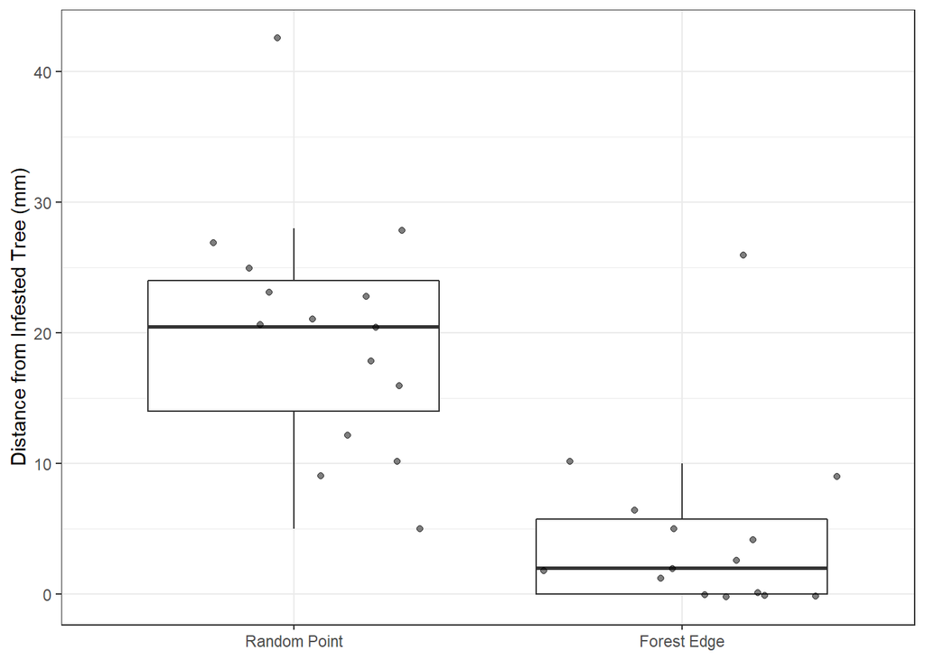

```r
ggplot(data = worms_long, aes(x=condition, y = distance)) +
  geom_boxplot(outlier.shape = NA) + #boxplot
  geom_jitter(alpha=0.5) + #show raw data
  scale_x_discrete(labels = c("Random Point", "Forest Edge")) + #add descriptive labels
  ylab(label = "Distance from Infested Tree (mm)") + #edit y axis label
  theme_bw() +
  theme(axis.title.x = element_blank()) #remove x axis title
```

**Write down your prediction(s) about webworm preference of forest edges.**

## Conduct t-test

Using the function `t.test`, conduct a two-sample t-test assuming unequal variances.

**What are your null and alternative hypotheses?**

**Based on the results of the t-test, do webworms preferentially choose forest edge trees?**

# Exercise 3.2 Are Webworm Infested Trees Clumped Throughout the Landscape?

A second analysis can be made using the aerial photograph to determine whether fall webworm-infested trees exhibit a clumped distribution. This can be determined using the T-square index of spatial pattern, termed C (Ludwig and Reynolds, 1988).

From the randomly selected points used in the previous analysis, determine the distance from that point to the nearest infested tree ($x_i$). From that tree ($x_i$), determine the distance (in mm) to the nearest infested neighbour ($y_i$).

```r
worms %>% select(Observation, x, y, d_infested_tree, d_nearest_infested_neighbour)
```

```
##    Observation  x  y d_infested_tree d_nearest_infested_neighbour
## 1            1  7  1            18.0                          7.0
## 2            2 18  5            42.5                          6.0
## 3            3 19  2            20.5                          3.0
## 4            4  6  9             5.0                         35.0
## 5            5  6  2             9.0                          7.0
## 6            6  5 13            23.0                         11.0
## 7            7  6 13            28.0                         11.0
## 8            8  4 20            25.0                          5.0
## 9            9  7 12            27.0                         13.0
## 10          10  5  0            16.0                          7.0
## 11          11  8 16            21.0                         13.5
## 12          12 10 19            23.0                         13.5
## 13          13 16  1            10.0                          4.0
## 14          14  4  0            12.0                         12.5
## 15          15  3 13            20.5                         11.0
```

**What do you predict about the distribution of webworms on the landscape?**

## Calculate C

Use the following formula to calculate C (an index of spatial pattern) where n = the total number of sample points.

$$C = \sum[x_i^2/ (x_i^2 + 0.5y_i^2)] / n$$

C is approximately 0.5 for random patterns, significantly less than 0.5 for uniform patterns, and significantly greater than 0.5 for clumped patterns.

**What does your value of C indicate?**

To determine if the value of C is significantly different from 0.5, use the following z-test:

$$z = (C - 0.5) / [1/(12n)]^{0.5}$$

If z is greater than or equal to 1.96, then C is significantly different from half, or in other words, the webworm-infested trees are non-randomly distributed on the landscape.

**According to the z-test, are the webworm-infested trees distributed randomly or non-randomly on the landscape?**

# Questions

Question 3.1. Although tree mortality from webworm infestation is rare, indirect influences on host health such as increased disease susceptibility may be important for long-term host survival. Paying particular attention to forest fragmentation, discuss the possible interactions between webworm distribution and landscape structure. How might this interaction affect ecosystem processes? (HINT: see Turner et al., 1989.)

Question 3.2. Webworm outbreaks may cause widespread damage to trees and mast crops (fruits and nuts). White-tailed deer (Oidocoileus virginianus) populations in central Oklahoma depend heavily on mast production for winter forage. How might patterns of webworm damage influence patterns of deer survival? Draw a conceptual model of this interaction.

Question 3.3. Unlike pine bark beetles, fall webworms are known to use a large array of host species (Nothnagle and Schultz, 1987). However, some species, such as pecan (Carya illinoensis) and sweetgum (Liquidambar styraciflua), are chosen preferentially as hosts. In addition, some unpalatable tree species such as red cedar (Juniperus virginiana) are seldom (if ever) used by fall webworms. If individual trees of the preferred species were protected from webworm infestation when located in the midst of unpalatable species, how might this so-called “plant defense guild” (Atsatt and O’Dowd, 1976) influence landscape patterns of webworm infestation? How could you test this hypothesis?

# Conclusions

In this lab you have seen and used different techniques for analyses of the effects of landscape structure and ecosystem function on organisms as well as the feedbacks that organisms have on the structure and function of ecosystems and landscapes. Both modeling and direct observation of organism distribution and landscape structure and function are important tools in this endeavor. There are numerous other examples in the literature; however, most work of this sort is conducted in the field (or in a model parameterized with field data) rather than in the laboratory. Nevertheless, laboratory data can also be useful to understand some of the finer-scale mechanisms that may be driving a particular system. While it may seem intuitively obvious that organisms can influence ecosystem processes and landscape structure, much work is still needed to understand the mechanisms behind these effects.

# Reproducibility

```r
Sys.time()
```

```
## [1] "2021-09-14 12:42:45 PDT"
```